# Reproducible data practices

Mahek Shah

2024-06-06

# 1 What is reproducibility? Why does it matter?

- Reproducibility means different things depending on the context. For us, in the context of bioinformatics and computational oncology, reproducibility means to provide enough information (data, code, methods, etc.) to allow someone to replicate the exact analysis and arrive at the same results.

> Reproducibility = Obtaining the same results when using the **same** code, data and *conditions of analysis.*
- Reproducibility doesn’t always mean that the analysis/result is correct! It just makes sure that the research is transparent.
- It is the minimum requirement for good data science. *BUT this alone is not sufficient.*

> Replicability = Obtaining similar results across studies using **different data**.
- A replicable study can show that the original study was reliable.
- Together, reproducibility and replicability enhance the reliability of the results. This acts as a quality check and reduces bias.

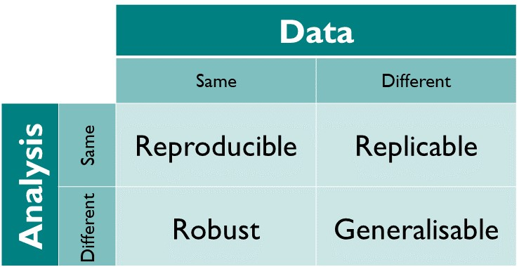

Source: https://book.the-turing-way.org

## 1.1 The reproducibility crisis:

> According to a study published in *Nature* in 2016, >70% researchers failed to reproduce someone else’s work and >50% failed to reproduce their own work (Survey of ~1500 researchers).
- Scientific papers often don’t have enough information to allow for reproducibility of the results.
- This leads to decreased reliability of published literature and causes distrust.

## 1.2 Barriers for reproducible research

[figure not shown]

Common Barriers to reproducible research as reported by Monya Baker (https://doi.org/10.1038/533452a)

## 1.3 How to boost reproducibilty

[figure not shown]

Boosting reproducibility as reported by Monya Baker (https://doi.org/10.1038/533452a)

# 2 Project organization

## 2.1 Why is organization important?

- It saves time by making things easier to find.
- This is acheived by defining a standard for yourself/the lab to make the organization more predictable.
- No, you can’t just “search” for something in the files because:
  1. File names might not be descriptive.
  2. Not every file is searchable.
  3. You might not know what exactly to search for.

## 2.2 Best practices when organizing a project:

### 2.2.1 Document EVERYTHING!

- Yes, even things that don’t work.
- But how?
  - COMMENT!!
    - Comments are a sign that you are thoughful of what you are doing.
    - The goal should be to explain **why** you took each step in the analysis - not just what that step is.
    - Make meaningful comments - comments should add context and explantion to the code. Don’t just duplicate the code.
    - Include references wherever applicable - especially at places where you might have copied the code from somewhere.
    - Write comments while you are writing your code.

> While updating code, remember to update comments!
- DOCUMENT!
  - Maintain a README.md file and regularly update it.
  - If using an R markdown file to code - start the markdown by providing essential information about the project and anything that needs to be known before looking at the code.

### 2.2.2 Essential folders/directories for any project

- Use a lot of folders and directories to organize the project.
- Keep projects separated and keep sections within a project separate.
- README, Data, Code, Figures, Results

#### 2.2.2.1 README.md

- README files include essential information about a project that another user should know about.
- This would be the first file anyone would read when trying to understand your project.
- What a README file should include:
  - Project title - make it informative.
  - Project summary - including information of any specific methods/techniques used.
  - Scripts used - If multiple scripts are used in a projects, introduce what each one does.
  - Project organization - if the file need to be read in a specific format.
- Other things which could be included:
  - More details! - always appreciated. Any other details which made make it easy for someone to read and use your project.
  - Future directions?
  - Any specific challenges faced?

#### 2.2.2.2 Data Folder

- Only big files go here! These files are used repeatedly.
- Raw -> This usually from external sources. Try not to modify this. To avoid modifications, you can change the settings to make it unmodifiable.
- Separate subfolder/s for processed files.
- Use subdirectories by processing stage, date or sample.

> *It is often the easiest to process all files in a folder together; organize by units of work*

### 2.2.3 Naming files and folders

[figure not shown]

This is an example of what not to do!

What you should do:  
- Pick a file naming convention. It doesn’t have to be the same as others but make sure it meets some basic criteria listed below!

- Make it informative.Should know what it is even without opening (*preferably!*)

**Jenny Bryan’s standard:**

#### 2.2.3.1 Machine friendly:

1. Avoid spaces  
   - Use underscores or dashes

```
RRBS_data_analysis.R
```

*instead of*

```
RRBS data analysis.R
```

2. Use standard characters only!  
   - letters, numbers, underscores and dashes.  
   - Use periods only for file extensions.  
   - Avoid using special characters.

```
Differential_methylation.R
```

*instead of*

```
Differential.methylation.R
```

3. Be consistent with case!  
   - Don’t have two files with same name which only differ in case.  
   - Case may/may not have meaning, depends on the programming language and OS.
4. Globbing  
   - Have multiple chunks in file names. Separate chunks with underscores.  
   - This also allows the use of wildcards (`*`, and others) to call all files that start or end with specific characters.  
   - Globbing allows to select file which match a “pattern”  
   - More information:
   - https://en.wikipedia.org/wiki/Glob_(programming)
   - https://github.com/begin/globbing?tab=readme-ov-file#what-is-globbing
- What’s even better than Globbing? - **regex** or regular expression.
  - Allows to extract information from file names.
  - Could be easily parsed into a dataframe using R or any othe programming language.
  - Makes things very easy for you and others!

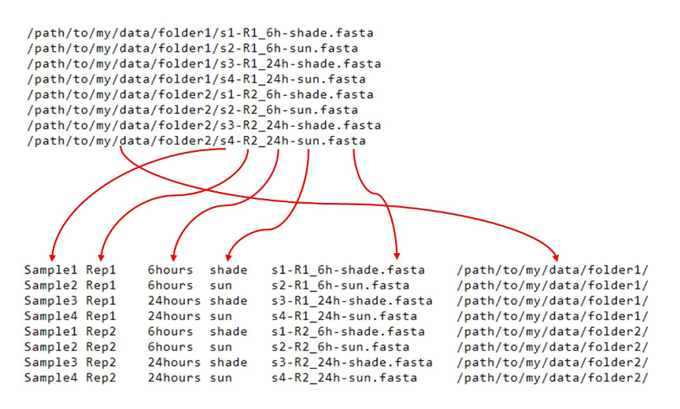

*Example of regex file naming.* Source: https://csiro-data-school.github.io/regex/01-intro/index.html

#### 2.2.3.2 Human friendly:

1. Use long descriptive names (short names can be tempting) - to be able to know what each file is without opening!

**Don’t:**

```
Analysis1.sh
Analysis2.sh
```

**Do:**

```
Alignment_Human_Genome.sh
Alignment_Mouse_Genome.sh
```

#### 2.2.3.3 Sortable and computable :

1. Use numbers for sorting. Use 01, 02 (left pad).
2. Use ISO 8601 standard dates (year-month-date or YYYY-MM-DD) which is easier for sorting.

```
01.adapter_trimming.sh
02.human_genome_alignment.sh

#Don't:

10.trimmed.txt
1.stuff-a.csv
2.stuff-b.csv
```

Also:

```
2024-03-01_plasmid_sequence.txt
2024-04-27_cell-line_sequence.txt

#Don't

01-15-2024-backup.csv
22-05-2024_foo.R
```

#### 2.2.3.4 For files received from someone else.

- It is usually not advisable to rename them because the original names are easier to track in conversation.
- *When renaming :* Use scripts to track the changes made. **Only rename when absolutely necessary!!!**

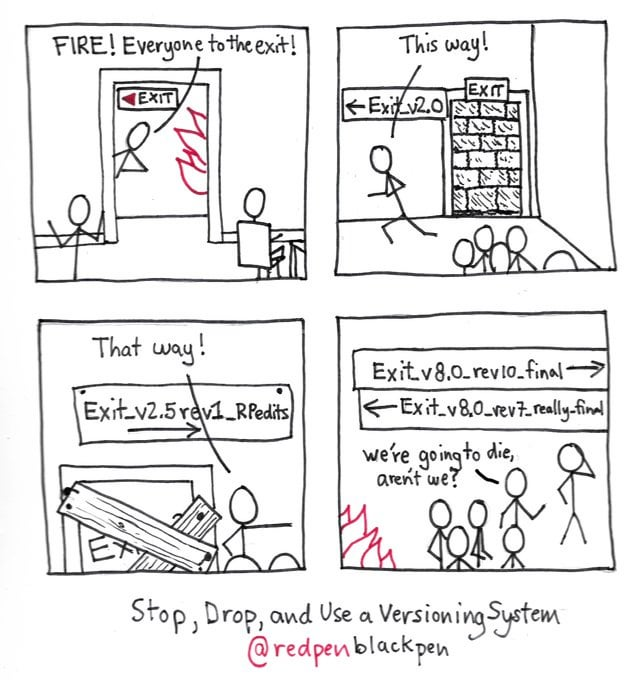

**Future you will appreciate the time invested in naming files!**

# 3 Strategies for Data Sharing

- data = all information to remake, interpret or use any part of the analysis i.e.
  - code(versions, specific commands ran, code for preprocessing, post processing, visualization),
  - metadata (about the sequencing and all the samples),
  - documentation,
  - data (raw, processed).
- Maintain both raw and processed data and deposit them at appropriate repositories.
- Be mindful of patient privacy when working with human subjects’ data. **Especially when working with rare disease.**
- Documentation:: Provide contextual information
  - Description of the data - origin of the data, software used to prepare it?
  - Contents and format - is it raw/processed? what does each column/variable mean. what do NA values mean?
  - How should the data be used?

Shared data should be *FAIR* (https://www.go-fair.org/fair-principles/)

## 3.1 **F**indable:

- Data should be easy to find by humans and computers.
- Data and metadata should be linked and indexed.
- Use a data repository: provides unique identifiers to data (like DOI) which can be cited.
- Complementary sharing platforms - university/lab server, GitHub(only for code).

## 3.2 **A**ccessible:

- Clear instructions to obtain the data.
- The repository should ideally be free to access.

## 3.3 **I**nteroperable:

- Plain text files are much better than special/proprietary format file like Excel, Matlab.
- Consider using ontologies to obtain shared vocabulary! There are multiple terms people can use to refer to the same thing.

## 3.4 **R**eusable:

- Make sure that the data/metadata have enough documentation.
- Data/metadata should be in relevant format.

> Make a plan/lab-wide policy and stick to it! Naming, organizing, sharing data files and how will you store/backup data

# 4 Organizing code in scripts and notebooks

- Read and use style guides:: https://style.tidyverse.org/
- Important style points to think about:
  - Variable and function name
  - indentation and spacing - tabs vs spaces, space before and after brackets & =
  - commenting style

```
data = read.csv("/path/to/file")
data=read.csv("/path/to/csv")
```

- Use markdowns and notebooks:
  - helps organize code into chunks.
  - allows you to publish results as pdf, html or word documents.
- Scripts are better for repititive tasks.

## 4.1 General plan for a notebook/script

Start with a descriptive header  
- include the purpose of that script/notebook  
- any other essential information

Code setup  
- Load all the packages up front at the top of the script instead of having random chunks of code with `library()`  
- Any other constant parameters.  
- Use R projects to setup the project environment.  
- **PLEASE** don’t start with `setwd()`. Always use relative file paths!!

- More accepted way to navigate through directories: Use the *here* R package.

```r
library("here")

#Very similar to file.path
here("data", "raw")
```

Code and Content  
- Break-up the code into appropriate chunks and headings

Other references:  
1. Reproducibility and Replicability in Science. - https://www.ncbi.nlm.nih.gov/books/NBK547546/#  
2. 1,500 scientists lift the lid on reproducibility - https://doi.org/10.1038/533452a  
3. Vince Buffalo: (https://www.oreilly.com/library/view/bioinformatics-data-skills/9781449367480/)  
4. Jenny Bryan: https://speakerdeck.com/jennybc/how-to-name-files  
5. Danielle Navarro: https://slides.djnavarro.net/project-structure  
6. Comments in code: best practices and 4 mistakes to avoid - https://swimm.io/learn/code-collaboration/comments-in-code-best-practices-and-mistakes-to-avoid  
7. FAIR principles - https://www.go-fair.org/fair-principles/